# Statistical Natural Language Processing in R

Bennett Kleinberg

Sentiment analysis

## Aim

Measuring the emotional tone (sentiment) that is expressed in a document.

- categorical: positive, neutral, negative
- continuous sentiment: e.g., -3.17, 1.89

Closely related to emotion analysis.

## Main approaches

1. Pre-defined word lists (lexicons)
2. Pre-trained models

## Basic sentiment analysis

1. tokenise text
2. construct a lexicon of sentiment words
3. judge the sentiment words
4. match tokens with sentiment lexicon

Example: travel blogs (LLM generated)

## 1. tokenisation

```r
blogs = fread('/Users/bennettkleinberg/GitHub/snlp/data/travel_blogs.csv')

example_1 = tokens(blogs$gpt_content[1])
```

> Title: A Whirlwind Journey Through the UK: From Sunshine to Rainclouds and Back to Sunshine**—, the United Kingdom! A land steeped in history, culture, and the promise of endless adventure. As I touched down at Heathrow Airport, the excitement surged through me like a bolt of lightning.[…]

## 2. lexicon of sentiment words

- do all words have a potential sentiment?
- maybe focus on adjectives/adverbs, maybe verbs?

Many sentiment lexicons already exist

## 2. lexicon of sentiment words

The `lexicon` [package](https://github.com/trinker/lexicon)

```r
head(lexicon::hash_sentiment_nrc[, 1], 10)
```

```
## Key: <x>
##               x
##          <char>
##  1:     abandon
##  2:   abandoned
##  3: abandonment
##  4:        abba
##  5:   abduction
##  6:    aberrant
##  7:  aberration
##  8:       abhor
##  9:   abhorrent
## 10:     ability
```

```r
head(lexicon::hash_sentiment_slangsd[, 1], 10)
```

```
## Key: <x>
##                              x
##                         <char>
##  1:                        a a
##  2:      a bad amount of money
##  3:               a bad mother
##  4:    a bad taste in my mouth
##  5:           a bag o' beagles
##  6: a bag of old and moldy ass
##  7:                   a barlow
##  8:                   a barney
##  9:                   a batman
## 10:                    a bitch
```

## lexicon::hash_sentiment_socal_google

```r
head(lexicon::hash_sentiment_socal_google[,1], 10)
```

```
## Key: <x>
##                   x
##              <char>
##  1:        a pillar
##  2:         ab liva
##  3:            able
##  4:   above average
##  5: above mentioned
##  6:        abrasive
##  7:          absent
##  8:        absolute
##  9:        abstract
## 10:          absurd
```

## 3. judge the sentiment words

Common strategy

- crowdsourced annotation
- decide on a judgment scale
- multiple judgments per word
- assess inter-rater reliability

## 3. judge the sentiment words

Again: mostly already done for you

```r
head(lexicon::hash_sentiment_nrc, 10)
```

```
## Key: <x>
##               x     y
##          <char> <int>
##  1:     abandon    -1
##  2:   abandoned    -1
##  3: abandonment    -1
##  4:        abba     1
##  5:   abduction    -1
##  6:    aberrant    -1
##  7:  aberration    -1
##  8:       abhor    -1
##  9:   abhorrent    -1
## 10:     ability     1
```

Binary judgment: -1 or 1

## Scale judgments

```r
head(lexicon::hash_sentiment_slangsd, 10)
```

```
## Key: <x>
##                              x     y
##                         <char> <num>
##  1:                        a a  -0.5
##  2:      a bad amount of money  -0.5
##  3:               a bad mother  -0.5
##  4:    a bad taste in my mouth  -0.5
##  5:           a bag o' beagles  -0.5
##  6: a bag of old and moldy ass  -0.5
##  7:                   a barlow  -0.5
##  8:                   a barney  -0.5
##  9:                   a batman   0.5
## 10:                    a bitch  -0.5
```

Finer judgment: -1.00, -0.50, 0.50, 1.00

## Continuous judgment

```r
head(lexicon::hash_sentiment_socal_google, 10)
```

```
## Key: <x>
##                   x          y
##              <char>      <num>
##  1:        a pillar  2.9045431
##  2:         ab liva -0.9578700
##  3:            able  2.6393740
##  4:   above average  3.2150018
##  5: above mentioned  2.5815803
##  6:        abrasive  1.6751913
##  7:          absent  0.4850649
##  8:        absolute  0.4737880
##  9:        abstract  2.0068557
## 10:          absurd -3.7778744
```

## 4. match tokens with sentiment lexicon

One sentiment score for each sentence.

```r
sentiment_table = sentimentr::sentiment(text.var = blogs$gpt_content[1]
                      , polarity_dt = lexicon::hash_sentiment_nrc)
```

For document-level sentiment: match words from sentiment lexicon, then calculate the average sentence sentiment for a document.

## Document-level sentiment

```r
sentiment_table[, mean(sentiment), .(element_id)]
```

```
## Key: <element_id>
##    element_id        V1
##         <int>     <num>
## 1:          1 0.2473638
```

## Valence shifters

- 1 = negator (not, never, …)
- 2 = amplifier (very, totally, …)
- 3 = deamplifier (hardly, barely, …)
- 4 = adversative conjunction (but, however, …)

## Within the `lexicon` package

```r
lexicon::hash_valence_shifters
```

```
## Key: <x>
##               x      y
##          <char> <char>
##   1: absolutely      2
##   2:      acute      2
##   3:    acutely      2
##   4:      ain't      1
##   5:       aint      1
##  ---
## 136:    whereas      4
## 137:      won't      1
## 138:       wont      1
## 139:   wouldn't      1
## 140:    wouldnt      1
```

## Control these in the `sentiment` function

```r
sentiment_table_2 = sentimentr::sentiment(text.var = blogs$gpt_content[1]
                      , polarity_dt = lexicon::hash_sentiment_nrc
                      , valence_shifters_dt = lexicon::hash_valence_shifters
                      , amplifier.weight = 0.8
                      , adversative.weight = 0.25
                      , n.before = 2
                      , n.after = 2)


sentiment_table_2
```

```
## Key: <element_id, sentence_id>
##     element_id sentence_id word_count  sentiment
##          <int>       <int>      <int>      <num>
##  1:          1           1         19  0.9176629
##  2:          1           2         12  1.1547005
##  3:          1           3         17  0.0000000
##  4:          1           4         27  0.0000000
##  5:          1           5         14  0.5345225
##  6:          1           6         19  0.2294157
##  7:          1           7         20  0.2236068
##  8:          1           8         36  0.8333333
##  9:          1           9         12  0.0000000
## 10:          1          10          6  0.4082483
## 11:          1          11         31  0.7184212
## 12:          1          12          2  0.0000000
## 13:          1          13         13  0.3328201
## 14:          1          14         18  0.0000000
## 15:          1          15         16  0.2497500
## 16:          1          16         16  0.0000000
## 17:          1          17         22  0.4264014
## 18:          1          18         12  0.0000000
## 19:          1          19         25 -0.4000000
## 20:          1          20         19 -0.2294157
## 21:          1          21         17  0.2425356
## 22:          1          22         25 -0.2000000
##     element_id sentence_id word_count  sentiment
```

## Different setups

```r
sentimentr::sentiment(text.var = blogs$gpt_content[1]
                      , polarity_dt = lexicon::hash_sentiment_nrc
                      , valence_shifters_dt = lexicon::hash_valence_shifters
                      , amplifier.weight = 0.8
                      , adversative.weight = 0.25
                      , n.before = 5
                      , n.after = 5)
```

```
## Key: <element_id, sentence_id>
##     element_id sentence_id word_count   sentiment
##          <int>       <int>      <int>       <num>
##  1:          1           1         19  0.91766294
##  2:          1           2         12  1.15470054
##  3:          1           3         17  0.00000000
##  4:          1           4         27  0.00000000
##  5:          1           5         14  0.53452248
##  6:          1           6         19  0.04588315
##  7:          1           7         20  0.22360680
##  8:          1           8         36  0.83333333
##  9:          1           9         12  0.00000000
## 10:          1          10          6  0.40824829
## 11:          1          11         31  0.71842121
## 12:          1          12          2  0.00000000
## 13:          1          13         13  0.33282012
## 14:          1          14         18  0.00000000
## 15:          1          15         16  0.24975000
## 16:          1          16         16  0.00000000
## 17:          1          17         22  0.42640143
## 18:          1          18         12  0.00000000
## 19:          1          19         25 -0.40000000
## 20:          1          20         19 -0.22941573
## 21:          1          21         17  0.24253563
## 22:          1          22         25 -0.20000000
##     element_id sentence_id word_count   sentiment
```

## No valence shifters

```r
sentimentr::sentiment(text.var = blogs$gpt_content[1]
                      , polarity_dt = lexicon::hash_sentiment_nrc
                      , valence_shifters_dt = NULL)
```

```
## Key: <element_id, sentence_id>
##     element_id sentence_id word_count  sentiment
##          <int>       <int>      <int>      <num>
##  1:          1           1         19  0.9176629
##  2:          1           2         12  1.1547005
##  3:          1           3         17  0.0000000
##  4:          1           4         27  0.0000000
##  5:          1           5         14  0.5345225
##  6:          1           6         19  0.2294157
##  7:          1           7         20  0.2236068
##  8:          1           8         36  0.8333333
##  9:          1           9         12  0.0000000
## 10:          1          10          6  0.4082483
## 11:          1          11         31  0.7184212
## 12:          1          12          2  0.0000000
## 13:          1          13         13  0.5547002
## 14:          1          14         18  0.0000000
## 15:          1          15         16  0.0000000
## 16:          1          16         16  0.0000000
## 17:          1          17         22  0.4264014
## 18:          1          18         12  0.0000000
## 19:          1          19         25 -0.4000000
## 20:          1          20         19 -0.2294157
## 21:          1          21         17  0.2425356
## 22:          1          22         25 -0.6000000
##     element_id sentence_id word_count  sentiment
```

## Different sentiment word list

```r
sentimentr::sentiment(text.var = blogs$gpt_content[1]
                      , polarity_dt = lexicon::hash_sentiment_sentiword
                      , valence_shifters_dt = lexicon::hash_valence_shifters
                      , amplifier.weight = 0.8
                      , adversative.weight = 0.25
                      , n.before = 5
                      , n.after = 5)
```

```
## Key: <element_id, sentence_id>
##     element_id sentence_id word_count   sentiment
##          <int>       <int>      <int>       <num>
##  1:          1           1         19  0.05735393
##  2:          1           2         12  0.14433757
##  3:          1           3         17  0.17432248
##  4:          1           4         27  0.32836797
##  5:          1           5         14  0.06013378
##  6:          1           6         19  0.04588315
##  7:          1           7         20  0.18633900
##  8:          1           8         36  0.28125000
##  9:          1           9         12  0.21650635
## 10:          1          10          6 -0.12757759
## 11:          1          11         31 -0.02245066
## 12:          1          12          2  0.00000000
## 13:          1          13         13  0.06933752
## 14:          1          14         18 -0.05597929
## 15:          1          15         16 -0.15630208
## 16:          1          16         16  0.03125000
## 17:          1          17         22 -0.07995027
## 18:          1          18         12  0.00000000
## 19:          1          19         25 -0.39125000
## 20:          1          20         19 -0.17206180
## 21:          1          21         17 -0.17179607
## 22:          1          22         25 -0.19000000
##     element_id sentence_id word_count   sentiment
```

## Locate sentences

```r
sentimentr::get_sentences(blogs$gpt_content[1])
```

```
## [[1]]
##  [1] "**Title: A Whirlwind Journey Through the UK: From Sunshine to Rainclouds and Back to Sunshine**\n\n---\n\nAh, the United Kingdom!"
##  [2] "A land steeped in history, culture, and the promise of endless adventure."
##  [3] "As I touched down at Heathrow Airport, the excitement surged through me like a bolt of lightning."
##  [4] "This was a dream come true—a chance to explore the iconic sites of London, the rolling hills of the countryside, and the rugged charm of Scotland."
##  [5] "My heart was set on a journey that would be nothing short of magical."
##  [6] "**The Beginning: A Symphony of Sights**\n\nThe first few days in London were everything I hoped for and more."
##  [7] "The city was alive with the hustle and bustle of diverse crowds, each street corner offering something new to discover."
##  [8] "I stood in awe before the majestic Big Ben, took a leisurely stroll through the verdant expanse of Hyde Park, and found myself utterly enchanted by the history encapsulated within the walls of the British Museum."
##  [9] "The energy of the city was intoxicating, and I reveled in it."
## [10] "The culinary scene was a revelation!"
## [11] "At Borough Market, I indulged in a delightful array of global flavors, while an impromptu stop at a charming pub introduced me to the heartwarming experience of a traditional Sunday roast."
## [12] "The highlight?"
## [13] "Afternoon tea at a quaint little tearoom, complete with scones and clotted cream."
## [14] "London was painting itself as a gastronomic paradise, and I was more than willing to sample its palette."
## [15] "**The Middle: Storm Clouds Gather**\n\nHowever, as my journey continued, the idyllic vision began to waver."
## [16] "The fabled British weather, known for its unpredictability, turned from a mild curiosity to an adversary."
## [17] "Day after day, the skies were shrouded in a persistent gray, and relentless rain dampened both my spirits and my exploring plans."
## [18] "My carefully curated itinerary lay crumpled in the wake of incessant downpours."
## [19] "A planned trip to Stonehenge was marred by muddy fields and a fog so thick, it obscured the ancient stones I had longed to see."
## [20] "My journey north to the Lake District was similarly afflicted, the stunning vistas hidden behind a curtain of drizzle."
## [21] "Even Edinburgh, with its brooding castle perched atop volcanic rock, seemed to glower under the overcast sky."
## [22] "As if the weather's betrayal wasn't enough, my phone succumbed to an untimely demise, leaving me adrift in a foreign land without the comfort of"
##
## attr(,"class")
## [1] "get_sentences"           "get_sentences_character"
## [3] "list"
```

Dictionaries in general

## Idea

Word matching (lookup in reference list).

Common for psycholinguistic constructs (e.g., LIWC).

## Your own dictionary

Suppose you want to create your own dictionary:

- to measure “hype” in academic writing
- with a list of words that belong to higher-order categories

Taken from: Millar, Batalo, and Budgell (2022)

*Beware of the validity trap!*

## Creating a dictionary in R

```r
hype_dict = quanteda::dictionary(list(importance = c("compelling", "critical", "crucial", "essential",  "foundational" , "fundamental", "imperative", "important", "indispensable", "invaluable", "key", "major", "paramount", "pivotal", "significant","strategic" , "timely", "ultimate", "urgent", "vital")
                                      , novelty = c("creative" , "emerging" , "first" , "groundbreaking", "innovative", "latest", "novel", "revolutionary" , "unique" , "unparalleled" ,  "unprecedented")
                                      , rigor = c("accurate", "advanced", "careful", "cohesive" , "detailed", "nuanced", "powerful", "quality", "reproducible", "rigorous", "robust", "scientific", "sophisticated", "strong", "systematic")
                                      )
                                 )
```

## Store this as a YAML (.yml) file

```r
write_yaml(x = hype_dict
           , file = './hype_dict.yaml')
```

## Using your dictionary

```r
library(quanteda)

hype_dict = dictionary(file = "/Users/bennettkleinberg/GitHub/snlp/data/hype_dict.yml")

c1 = corpus(blogs$gpt_content)

c_tok = tokens(c1
               , remove_punct = T)

c_dfm = dfm(c_tok
            , tolower = T)

dict_match = dfm_lookup(c_dfm
                 , dictionary = hype_dict
                 , valuetype = 'glob')

dict_match
```

```
## Document-feature matrix of: 100 documents, 8 features (60.00% sparse) and 0 docvars.
##        features
## docs    importance novelty rigor scale utility quality attitude problem
##   text1          0       1     0     1       0       0        0       0
##   text2          0       1     0     0       2       2        0       0
##   text3          0       3     0     2       2       2        0       0
##   text4          0       1     0     1       1       0        0       0
##   text5          0       1     0     1       2       1        0       0
##   text6          0       1     0     1       2       1        0       1
## [ reached max_ndoc ... 94 more documents ]
```

## Now: PRACTICAL III

- sentiment analysis
- wider emotion analysis
- working with existing dictionaries
- creating your own dictionary

Word embeddings

## Idea

Capturing semantics of words.

Without any supervision.

Based on our EuroCSS workshop: [A Gentle Introduction to Word Embeddings for the Computational Social Sciences](https://maximilianmozes.github.io/word-embeddings-workshop/)

## Abstraction of the problem

A single word can have different meanings:

- Death in Venice is my favorite **novel**.
- He came up with a **novel** idea.

Different meaning depending on context:

- Don’t use the trackpad, just use your **mouse**.
- My cat just caught a **mouse**.

## Word representations

- we can represent textual data as vectors
- each word can thus be placed in a vector space

Aim of word embeddings: move related words closer in vector space than unrelated words

## One-hot word encoding

```r
corpus_b = corpus(blogs$gpt_content[1:50])
dfm_2 = dfm(tokens_ngrams(tokens_select(x = tokens(corpus_b
                                                   , remove_punct = T
                                                   , remove_symbols = T)
                                        , pattern=stopwords('en')
                                        , selection= 'remove') , n=1))
t(dfm_2)
```

```
## Document-feature matrix of: 2,393 documents, 50 features (91.50% sparse) and 0 docvars.
##             features
## docs         text1 text2 text3 text4 text5 text6 text7 text8 text9 text10
##   title          1     1     0     1     1     1     1     1     1      0
##   whirlwind      1     0     0     1     1     0     1     0     1      0
##   journey        4     3     1     2     2     2     2     2     2      1
##   uk             1     2     3     2     4     3     1     3     1      4
##   sunshine       2     0     0     0     0     0     0     0     0      0
##   rainclouds     1     0     0     0     0     0     0     0     0      0
## [ reached max_ndoc ... 2,387 more documents, reached max_nfeat ... 40 more features ]
```

## Problem

Similarity between two one-hot encoded vectors is 0.

This is because we need the dot-product of the vectors:

$\text{cosine similarity}(\mathbf{A}, \mathbf{B}) = \frac{A \times B}{\sqrt{A \times A} * \sqrt{B \times B}}$

**We need a different representation of words.**

## Enter: word embeddings

- Instead of using one-hot vectors, assign each word to a dense vector representation
- If two words are semantically similar, their dot product should be high

*How do we find those embeddings?*

## Original approaches

- Glove Pennington, Socher, and Manning (2014)
- Word2Vec Mikolov et al. (2013)

## Word2Vec

- Skip-gram: given a specific word, estimate probability of context words
- Continuous-bag-of-words: given a set of context words, predict the center word

(for details, see the [EuroCSS slides](https://github.com/maximilianmozes/word_embeddings_workshop_resources/blob/master/slides/theo.pdf))

## Glove (Global Vectors)

- Based on co-occurrences

```r
ex_c = corpus(tolower(blogs$gpt_content[1:20]))
fcm(tokens_select(x = tokens(ex_c
                             , remove_punct = T
                             , remove_symbols = T)
                  , pattern=stopwords('en')
                  , selection= 'remove')
    , tri=F)
```

```
## Feature co-occurrence matrix of: 1,572 by 1,572 features.
##             features
## features     title whirlwind journey  uk sunshine rainclouds back ah united
##   title          0         8      33  31        3          1   11  6     12
##   whirlwind      8         0      23  19        2          1    6  5     10
##   journey       33        23      46 107       12          4   33 21     49
##   uk            31        19     107  45        3          1   29 15     41
##   sunshine       3         2      12   3        1          2    3  3      3
##   rainclouds     1         1       4   1        2          0    1  1      1
##   back          11         6      33  29        3          1    1  6     11
##   ah             6         5      21  15        3          1    6  0      6
##   united        12        10      49  41        3          1   11  6      3
##   kingdom       12        10      49  41        3          1   11  6     26
##             features
## features     kingdom
##   title           12
##   whirlwind       10
##   journey         49
##   uk              41
##   sunshine         3
##   rainclouds       1
##   back            11
##   ah               6
##   united          26
##   kingdom          3
## [ reached max_feat ... 1,562 more features, reached max_nfeat ... 1,562 more features ]
```

## For both approaches

- we fit a model that helps us obtain dense representations of each word
- word2vec: capture local context many times
- Glove: capture global context once

Both rely on the distributional hypothesis Harris (1954): “words occurring in the same context tend to have similar meanings”

## Working with Glove embeddings

```r
source('/Users/bennettkleinberg/GitHub/snlp/data/init_glove.R')

init_glove(dir = '/Users/bennettkleinberg/Documents/glove'
           , which_model = '6B'
           , dim=300)
```

```
## [1] "Looking for pretrained GloVe vectors in: /Users/bennettkleinberg/Documents/glove"
## [1] "Success - found GloVe objects in directory."
## [1] "--- initialising the 300d model ---"
## [1] "Success: initialised GloVe model as glove.pt"
```

## The embeddings dfm

```r
dim(glove.pt)
```

```
## [1] 400000    300
```

```r
rownames(glove.pt)[200:210]
```

```
##  [1] "early"     "according" "several"   "court"     "say"       "around"
##  [7] "foreign"   "10"        "until"     "set"       "political"
```

## Retrieving embeddings

```r
university_emb = as.vector(glove.pt[row.names(glove.pt) == 'university', ])
university_emb
```

```
##   [1] -0.1123500  0.0906560  0.4507500  0.3664900  0.0030079 -0.5842600
##   [7]  0.1199900 -0.4039100  0.7735500 -0.9738900 -0.1020600  0.0943080
##  [13]  0.4766700  0.1113500  0.6318400  0.8168100  0.1834100  0.0753780
##  [19]  0.1508200 -0.0671220  0.0258030 -0.5034900  0.1947800  0.8510100
##  [25] -0.6837900  0.9040900 -0.1404400 -0.0309790 -0.1902900 -0.7404600
##  [31]  0.6694600 -0.4309300 -0.3960700  0.9012700 -0.8238500  0.0672280
##  [37]  0.1903300  0.2838100 -0.2721800 -0.1300200  0.2845500 -0.2623200
##  [43] -0.5134100  0.5287800 -0.4137600 -0.2690100  0.1620300  0.7484000
##  [49] -0.1380600 -0.0794280 -0.3442700  0.2037000  0.0668750 -0.1599600
##  [55]  0.3091900  0.0495510  0.9105200 -0.1846900 -0.3417700 -0.3102700
##  [61] -0.6258500  0.4490200  0.5083400  0.4622900 -0.0138200 -0.4143300
##  [67]  0.1787600  0.3458500  0.0390060 -0.5651700 -0.0550030  0.0486400
##  [73]  0.5530600 -0.3080600 -0.6216100  0.1322200  0.0884470  0.3731800
##  [79]  0.3591600 -0.0653470  0.1791600 -0.3149800 -0.9578200  0.1164500
##  [85] -0.2544200  0.2059800  0.2522100  0.0021477  0.0699690  0.0662730
```

[output cut: 35 more lines]

## Nearest neighbours

```r
library(quanteda.textstats)

cos_sim_vals = textstat_simil(glove.pt
                              , selection = c("university"
                                              , "beach"
                                              , "bank")
                              , margin = "documents"
                              , method = "cosine")
```

## Top 25 neighbours for “university”

```r
head(sort(cos_sim_vals[,1], decreasing = TRUE), 25)
```

```
##    university     professor      graduate       college       harvard
##     1.0000000     0.7463630     0.7044455     0.6996859     0.6874451
##       faculty          yale  universities        campus     doctorate
##     0.6825277     0.6606154     0.6385826     0.6320205     0.6097204
##      stanford       student     graduated       studies       science
##     0.6004673     0.5970513     0.5920379     0.5913025     0.5849513
##       cornell     princeton        school undergraduate     institute
##     0.5826447     0.5791559     0.5767619     0.5731509     0.5731454
##      students    graduating       studied    georgetown        degree
##     0.5693991     0.5659560     0.5610755     0.5545408     0.5524527
```

## Top 25 neighbours for “beach”

```r
head(sort(cos_sim_vals[,2], decreasing = TRUE), 25)
```

```
##      beach       palm    beaches       fla.     delray    florida     resort
##  1.0000000  0.7012955  0.6163590  0.6030691  0.5142482  0.5057483  0.4883393
##       surf      shore       sand       tahp       golf    seaside     shores
##  0.4866089  0.4710938  0.4681904  0.4643037  0.4560607  0.4525903  0.4470195
##      miami     myrtle    pompano     marina      ocean     island      coast
##  0.4462534  0.4433399  0.4426478  0.4410466  0.4393163  0.4389578  0.4385522
## lauderdale  pensacola    waikiki    boynton
##  0.4380627  0.4353465  0.4298502  0.4293239
```

## Top 25 neighbours for “bank”

```r
head(sort(cos_sim_vals[,3], decreasing = TRUE), 25)
```

```
##         bank        banks      banking      central       credit      bankers
##    1.0000000    0.7039026    0.6014180    0.5375902    0.5313779    0.5164543
##    financial   investment      lending     citibank     monetary        loans
##    0.4999611    0.4982147    0.4970785    0.4939171    0.4813266    0.4783002
##       lender   securities        funds      finance         hsbc      deposit
##    0.4733866    0.4681096    0.4674762    0.4674404    0.4597526    0.4512991
##         west institutions     accounts         cash        money      interbk
##    0.4487057    0.4412474    0.4403611    0.4369415    0.4363054    0.4357756
##     currency
##    0.4342985
```

## Arithmetics with word embeddings

What if we could do “maths with meaning”?

Do semantic relationships hold true in embeddings?

## BERLIN - GERMANY + FRANCE

If: $\vec{BERLIN} \approx BERLIN$

$\frac{\vec{GERMANY}}{\vec{BERLIN}} :: \frac{\vec{FRANCE}}{\vec{?}}$

```r
berlin = as.vector(glove.pt[row.names(glove.pt) == 'berlin', ])
germany = as.vector(glove.pt[row.names(glove.pt) == 'germany', ])
france = as.vector(glove.pt[row.names(glove.pt) == 'france', ])
```

```r
mystery_1 = berlin - germany + france
mystery_1
```

```
##   [1]  0.1593480 -0.2449800 -0.3969100 -0.3693600  0.0408160  0.4310420
##   [7]  0.1436520 -0.5391020 -0.2657620 -0.8131200  0.1920340 -0.1880900
##  [13]  0.0948170 -0.1002900  0.3464600  0.3787300 -0.4898290  1.0012580
##  [19]  0.1593500  0.4696400 -0.5971800  0.1259300  0.2129760 -0.2240480
##  [25]  0.2632680 -0.2695700  0.4503100 -0.2765800  0.2060300  0.4942400
##  [31]  0.3017600 -0.7015923 -0.7801700  0.5599700 -0.6832100 -0.9021100
##  [37] -0.0564500 -0.2414550 -0.5759900 -0.1119110 -0.3866900 -0.2037000
##  [43] -0.0385500  0.2165500 -0.2987250  0.6085000 -0.1089500  0.7300900
##  [49] -0.3076650 -0.2265200  0.4095100 -0.1826300  0.7471180 -0.7209600
##  [55]  0.6595400 -0.1934100 -0.5467250  0.0000670  0.3715457 -0.8449400
##  [61] -0.3379400  0.3629950  0.1017800  0.2802000 -0.3472210 -0.2909400
##  [67]  0.4565720 -0.0773470 -0.4129500 -0.7792600  0.2421800 -0.5980787
##  [73] -0.0005120  0.0224300 -0.5563580  0.5590880  1.0116290  0.5257300
##  [79] -0.7774170 -0.0310030  0.0719760 -0.1657820  0.2271640  0.3705300
##  [85] -0.6682800 -0.3637330  0.2098200  0.4538230 -0.3972200 -0.4923200
```

[output cut: 35 more lines]

## Clostest neighbours to that vector?

```r
mystery = data.frame(matrix(mystery_1, nrow = 1, byrow = T))
names(mystery) = featnames(glove.pt)
mystery_dfm = as.dfm(mystery)

glove.pt = rbind(glove.pt, mystery_dfm)
row.names(glove.pt)[400001] = c('mystery_1')

cos_sim_vals_mystery = textstat_simil(glove.pt
                              , selection = c("mystery_1")
                              , margin = "documents"
                              , method = "cosine")
```

```r
head(sort(cos_sim_vals_mystery[,1], decreasing = TRUE), 10)
```

```
##          1      paris     france prohertrib     french   brussels     berlin
##  1.0000000  0.7907898  0.6829652  0.6757443  0.6265681  0.5365580  0.5024956
##         le   parisian  marseille
##  0.4737045  0.4493072  0.4470702
```

## Dynamic embeddings

But: Glove and Word2Vec are still static embeddings.

- new embeddings require re-training the models (and this requires substantial amounts of text data)
- enter: **Bidirectional Encoder Representations from Transformers (BERT)** Devlin et al. (2019)
- Aim: capturing contextual-dependencies (key: bidirectional context and attention mechanism)

## Workflow of current embeddings approaches

- large pre-trained language model (BERT, GPT, Llama)
- these models are trained to arrive at embeddings for sequences of words
- for a given input sequence, the models produce an embeddings representation
- For R: RBERT

## Via OpenAI with `rgpt3`

- we can also obtain text embeddings from the GPT models
- requires an API key!
- Package on GitHub: https://github.com/ben-aaron188/rgpt3

```r
devtools::install_github("ben-aaron188/rgpt3")
library(rgpt3)
rgpt_authenticate("/Users/bennettkleinberg/GitHub/rgpt3/R/access_key.txt")
```

## Obtaining embeddings from the GPT models

Dataset: narratives expressing worries about the pandemic Kleinberg, Vegt, and Mozes (2020), Vegt and Kleinberg (2020), Van Der Vegt and Kleinberg (2023), Mozes, Vegt, and Kleinberg (2021)

```r
rwwd = fread('/Users/bennettkleinberg/GitHub/snlp/data/real_world_worry_waves_dataset.csv')
```

```r
rwwd_emb = rgpt_embeddings(input_var = rwwd$text_long_wave1
                                , id_var = rwwd$id
                                , param_dimensions = 256)

[1] "Embedding: 1/1152"
[1] "Embedding: 2/1152"
[1] "Embedding: 3/1152"
[1] "Embedding: 4/1152"
[1] "Embedding: 5/1152"
[1] "Embedding: 6/1152"
```

## Resulting embeddings

```
##              dim_1      dim_2        dim_3        dim_4       dim_5
##              <num>      <num>        <num>        <num>       <num>
##    1:  0.001512289 0.06292129 -0.006810027  0.042608910 0.057944080
##    2:  0.016055878 0.09590197 -0.018952515  0.025516087 0.055942820
##    3: -0.008442108 0.08485567 -0.015789721  0.055819318 0.102818290
##    4: -0.014628169 0.10007212 -0.005409420  0.004045268 0.061772916
##    5: -0.071818285 0.02843625  0.002193221  0.004574491 0.066585620
##   ---
## 1148: -0.047735190 0.10905138  0.003723009  0.026439244 0.055735875
## 1149: -0.003269320 0.06100956 -0.022816436  0.050817620 0.002468082
## 1150: -0.067103230 0.03579266 -0.018808754 -0.016663756 0.024619458
## 1151: -0.001685198 0.08238468 -0.003208702  0.011625244 0.029163908
## 1152: -0.044972382 0.05411819 -0.005876512 -0.060105740 0.031615550
##               dim_6        dim_7        dim_8        dim_9       dim_10
##               <num>        <num>        <num>        <num>        <num>
```

[output cut: 622 more lines]

## Recap: embeddings

- game-changer in NLP
- transition from static embeddings (Glove, Word2Vec) to contextualised embeddings (BERT)
- very powerful for prediction
- current benchmark for capturing semantics in text representations
- but: data-hungry, unstable, non-interpretable (see [EuroCSS slides](https://github.com/maximilianmozes/word_embeddings_workshop_resources/blob/master/slides/limitations.pdf))

Topic modelling

## Aim

- uncover hidden themes in a collection of documents
- assumption: each document is a mixture of topics, and each topic is a distribution over words

## Two important approaches

1. Latent Dirichlet Allocation (LDA)
   - Document generation assumption: topics are first selected, then words are chosen from those topics
   - Bag-of-words approach: LDA ignores word order and context
   - the focus is on *document-term frequency* and *co-occurrences* within documents
   - key challenge: finding words that belong to the $k$ topics

In R: the [stm package for Structural Topic Modelling](https://cran.r-project.org/web/packages/stm/vignettes/stmVignette.pdf)

## Two important approaches

2. Embeddings-based topics
   - each document is represented by an embeddings vector
   - clustering approaches find *clusters* ($\approx$ topics) in the corpus of documents
   - TF-IDF is used to find central words for each cluster

Excellent approach: [BERTopic](https://maartengr.github.io/BERTopic/index.html) Grootendorst (2022)

## BERTopic

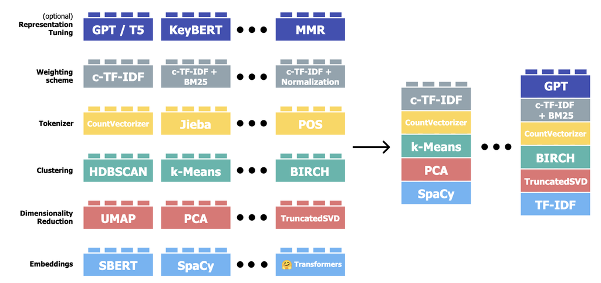

## k-means clustering

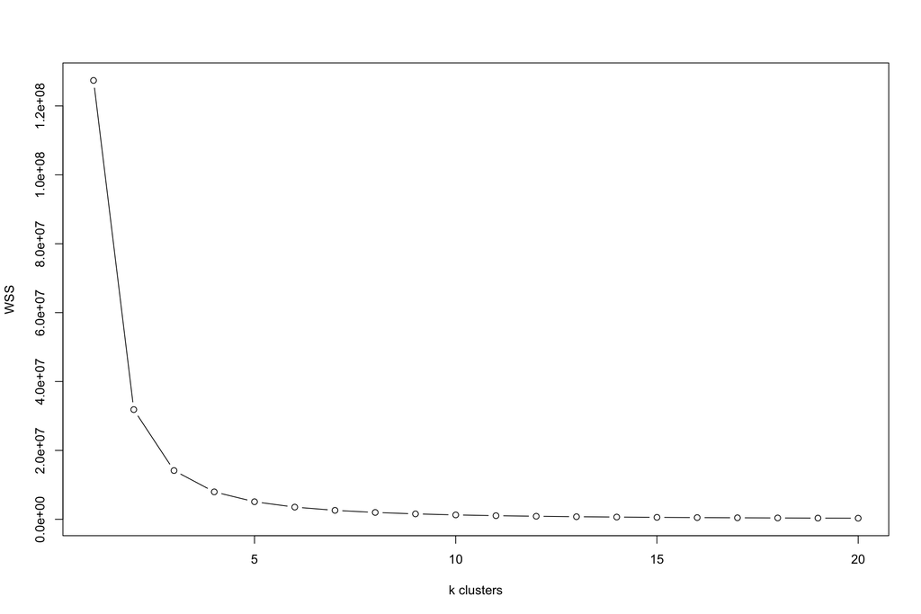

```r
wss = numeric()
for(i in 1:20){
  kmeans_model = kmeans(rwwd_emb
                        , centers = i
                        , iter.max = 20
                        , nstart = 10)
  wss[i] = kmeans_model$tot.withinss
}
plot(1:20, wss, type='b', xlab='k clusters', ylab='WSS')
```

## Silhoutte method

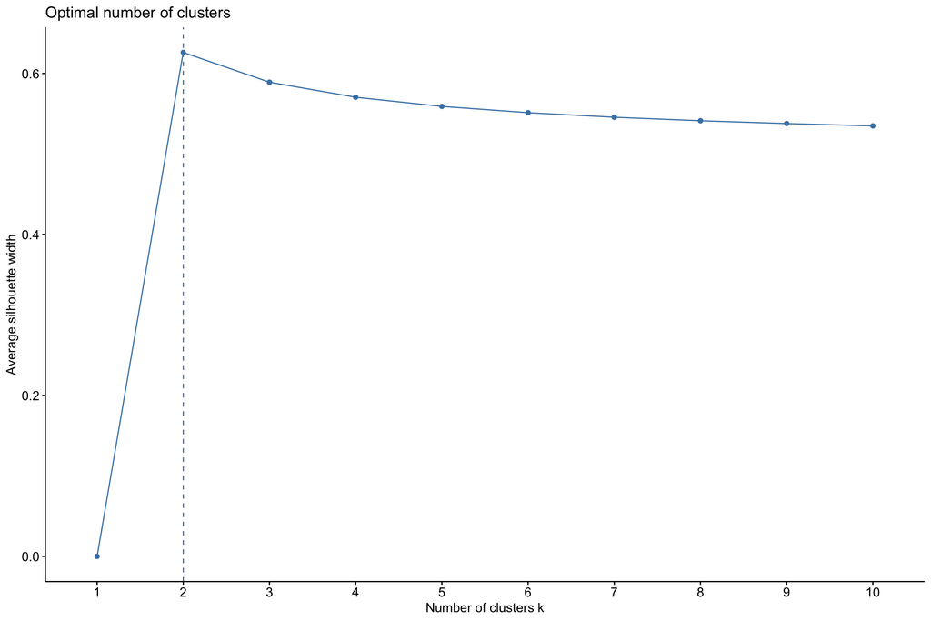

```r
factoextra::fviz_nbclust(rwwd_emb, kmeans, method = "silhouette")
```

## Fit k-means model

```r
kmeans_model_k_2 = kmeans(rwwd_emb
                          , centers = 2
                          , iter.max = 20
                          , nstart = 10)

# add topic clusters
rwwd$topic = kmeans_model_k_2$cluster
```

## Create a grouped corpus by topics

```r
rwwd_corpus = corpus(rwwd$text_long_wave1
                          , docvars = data.frame(cluster = rwwd$topic))

rwwd_corpus_grouped = corpus_group(rwwd_corpus
                                        , groups = cluster)

rwwd_corpus_grouped
```

```
## Corpus consisting of 2 documents and 1 docvar.
## 1 :
## "I’m still very worried about covid-19 at this moment in time..."
##
## 2 :
## "I am more worried about getting access to my normal healthca..."
```

## TF-IDF weighting of grouped corpus

```r
toks = tokens(tolower(rwwd_corpus_grouped)
              , remove_punct = T
              , include_docvars = T)

toks = tokens_select(toks
                     , pattern = stopwords('en')
                     , selection = 'remove')

ngrams = tokens_ngrams(x = toks
                       , n= 1:3)

dfm_1 = dfm_trim(dfm(ngrams)
                 , min_docfreq = 0.01
                 , docfreq_type = 'prop')

dfm_2 = dfm_wordstem(dfm_1)
```

```r
dfm_2
```

```
## Document-feature matrix of: 2 documents, 103,676 features (46.17% sparse) and 1 docvar.
##     features
## docs i’m still worri covid-19 moment time main member famili wife
##    1 171   126   579       33     94  299   24     54    382   16
##    2 101   111   616       16    112  288   27     55    386   18
## [ reached max_nfeat ... 103,666 more features ]
```

## Top TF-IDF terms by topic

```r
dfm_tfidf = dfm_tfidf(dfm_2
                      , scheme_tf = "count"
                      , scheme_df = "inverse")

topfeatures(dfm_tfidf, groups = cluster, n = 20)
```

```
## $`1`
## peopl_still_go          birth            via         eventu           base
##        3.61236        3.31133        2.70927        2.70927        2.10721
##          guess         attent           anim       tri_stay     know_peopl
##        2.10721        2.10721        1.80618        1.80618        1.80618
##           zoom          bubbl        tremend     conspiraci         wasn’t
##        1.50515        1.50515        1.50515        1.50515        1.50515
##  sooner_rather     news_worri        us_take     continu_go  direct_affect
##        1.50515        1.50515        1.50515        1.50515        1.50515
##
## $`2`
##        can_get_back        distanc_feel          mani_other          home_worri
##             2.40824             2.10721             2.10721             2.10721
##         famili_time       lockdown_also              relief             weekday
##             2.10721             2.10721             1.80618             1.80618
##        worri_effect social_distanc_feel           construct              panick
##             1.80618             1.80618             1.50515             1.50515
##            woefulli               juggl           loss_life           live_life
##             1.50515             1.50515             1.50515             1.50515
##           feel_calm            go_visit        situat_think       virus_anxious
##             1.50515             1.50515             1.50515             1.50515
```

## Recap: topic modelling

- seeks to identify hidden (latent) themes in documents
- various approaches to do this (e.g., DFM-based and embeddings-based)
- challenges: dimensionality, choosing $k$, dealing with non-assignable documents, labelling topics

Supervised learning with textual data

## Aim

- make predictions from $text \rightarrow outcome$
- plenty of examples with numerical data
- with textual data: always via text quantification first!

*This is where a lot of the hope on textual data lies.*

## Text quantification approaches

Main approaches:

1. Term frequency-based (ngrams): e.g., DFM, TFIDF
2. Dictionary-based: e.g., LIWC Boyd et al. (2022)
3. Embeddings-based: e.g., SBERT Reimers and Gurevych (2019), Universal Sentence Encodings Cer et al. (2018)

*Supervised learning implies labelled data!*

## Common logic

Steps in text classification:

1. split the data into a training and test set
2. train an algorithm on the training set (incl. cross-validation)
3. evaluate your final model on the test set
4. report performance metrics on the test set

## Machine learning flow in `caret`

```r
library(caret)

set.seed(123)

in_training = createDataPartition(y = data_ml$REWRITTEN
                                  , p = .8
                                  , list = FALSE)

training_data = data_ml[in_training, ]
testing_data = data_ml[-in_training, ]

model_svm = train(outcome_class ~ .
                  , data = training_data
                  , method = "svmLinear"
                  , trControl = trainControl(method = 'cv', number=5)
                  , preProcess = c('nzv'))

model_svm_pred = predict(model_svm, testing_data)

confusion_matrix = confusionMatrix(model_svm_pred, testing_data$outcome_class)
```

## Example

Dataset of truthful and deceptive narratives about weekend plans Kleinberg and Verschuere (2021)

```r
truth_lie =  fread('/Users/bennettkleinberg/GitHub/snlp/data/sign_events_data_statements.csv')

truth_lie[, .N, .(outcome_class)]
```

```
##    outcome_class     N
##           <char> <int>
## 1:             t   783
## 2:             d   857
```

## Key challenge in text classification

*Which text quantification (features) do we use?*

Let’s see how this works with a DFM and with embeddings.

## DFM as features

```r
truth_lie_corpus = corpus(truth_lie$q1
                          , docvars = data.frame(TL = truth_lie$outcome_class))

toks = tokens(tolower(truth_lie_corpus)
              , remove_punct = T
              , include_docvars = T)

toks = tokens_select(toks
                     , pattern = stopwords('en')
                     , selection = 'remove')

ngrams = tokens_ngrams(x = toks
                       , n= 1:3)

dfm_truth_lie = dfm_trim(dfm(ngrams)
                 , min_docfreq = 0.01
                 , docfreq_type = 'prop')

dfm_truth_lie_2 = dfm_wordstem(dfm_truth_lie)
```

```r
dfm_truth_lie_2
```

```
## Document-feature matrix of: 1,640 documents, 359 features (96.56% sparse) and 1 docvar.
##        features
## docs    littl brother get next saturday alway close parent love wed
##   text1     2       1   1    1        1     1     1      1    1   1
##   text2     0       0   0    0        0     0     0      0    0   0
##   text3     0       0   1    0        0     0     0      0    0   0
##   text4     0       0   0    0        0     0     0      0    0   0
##   text5     0       0   1    0        0     0     0      0    0   0
##   text6     1       0   0    0        0     0     0      0    0   0
## [ reached max_ndoc ... 1,634 more documents, reached max_nfeat ... 349 more features ]
```

## Using that DFM in `caret`

```r
# covert the dfm to a data.frame
data_ml = convert(dfm_truth_lie_2, to = 'data.frame')

# add the outcome variable (target variable) from the docvars
data_ml$TL = as.factor(dfm_truth_lie_2$TL)

# remove the "doc_id" variable
data_ml = data_ml[, -c(1)]

names(data_ml)
```

```
##   [1] "littl"               "brother"             "get"
##   [4] "next"                "saturday"            "alway"
##   [7] "close"               "parent"              "love"
##  [10] "wed"                 "take"                "old"
##  [13] "much"                "plan"                "partner"
##  [16] "go"                  "day"                 "famili"
##  [19] "friend"              "come"                "far"
##  [22] "celebr"              "excit"               "two"
##  [25] "one"                 "drive"               "minut"
##  [28] "london"              "2"                   "dinner"
##  [31] "near"                "live"                "probabl"
##  [34] "around"              "also"                "like"
##  [37] "recent"              "think"               "daughter"
##  [40] "bike"                "picnic"              "play"
##  [43] "park"                "tuesday"             "morn"
```

[output cut: 105 more lines]

## Splitting the data

```r
set.seed(123)

in_training = createDataPartition(y = data_ml$TL
                                  , p = .8
                                  , list = FALSE)

training_data = data_ml[in_training, ]
testing_data = data_ml[-in_training, ]
```

## Training on the training set

```r
model_svm = train(TL ~ .
                  , data = training_data
                  , method = "svmLinear"
                  , trControl = trainControl(method = 'cv', number=5)
                  , preProcess = c('nzv'))
```

## Evaluating the model on the test set

```r
model_svm_pred = predict(model_svm, testing_data)

confusionMatrix(model_svm_pred, testing_data$TL)
```

```
## Confusion Matrix and Statistics
##
##           Reference
## Prediction   d   t
##          d  96  45
##          t  75 111
##
##                Accuracy : 0.633
##                  95% CI : (0.5782, 0.6854)
##     No Information Rate : 0.5229
##     P-Value [Acc > NIR] : 3.782e-05
##
##                   Kappa : 0.2707
##
##  Mcnemar's Test P-Value : 0.008113
##
##             Sensitivity : 0.5614
##             Specificity : 0.7115
##          Pos Pred Value : 0.6809
##          Neg Pred Value : 0.5968
##              Prevalence : 0.5229
##          Detection Rate : 0.2936
##    Detection Prevalence : 0.4312
##       Balanced Accuracy : 0.6365
##
##        'Positive' Class : d
##
```

## Most diagnostic features

```r
varImp(model_svm)
```

```
## ROC curve variable importance
##
##   only 20 most important variables shown (out of 359)
##
##         Importance
## go          100.00
## excit        69.72
## home         56.48
## week         56.47
## just         50.49
## weekend      49.89
## realli       47.34
## get          47.28
## around       45.47
## plan         45.21
## hour         41.76
## can          41.12
## trip         41.04
## drink        40.87
## weather      40.15
## meal         40.04
## sister       39.96
## want         39.70
## take         38.59
## alway        36.67
```

## Embeddings as features

```r
truth_lie_emb = fread('/Users/bennettkleinberg/GitHub/snlp/data/truth_lie_embeddings.csv')

data_ml = merge(truth_lie_emb, truth_lie[, c("outcome_class", "id")], by='id')

# set the same variable name as above
data_ml$TL = as.factor(data_ml$outcome_class)

# remove the "id" and "outcome_class" variable
data_ml = data_ml[, -c("id", "outcome_class")]

names(data_ml)
```

```
##   [1] "dim_1"   "dim_2"   "dim_3"   "dim_4"   "dim_5"   "dim_6"   "dim_7"
##   [8] "dim_8"   "dim_9"   "dim_10"  "dim_11"  "dim_12"  "dim_13"  "dim_14"
##  [15] "dim_15"  "dim_16"  "dim_17"  "dim_18"  "dim_19"  "dim_20"  "dim_21"
##  [22] "dim_22"  "dim_23"  "dim_24"  "dim_25"  "dim_26"  "dim_27"  "dim_28"
##  [29] "dim_29"  "dim_30"  "dim_31"  "dim_32"  "dim_33"  "dim_34"  "dim_35"
##  [36] "dim_36"  "dim_37"  "dim_38"  "dim_39"  "dim_40"  "dim_41"  "dim_42"
##  [43] "dim_43"  "dim_44"  "dim_45"  "dim_46"  "dim_47"  "dim_48"  "dim_49"
##  [50] "dim_50"  "dim_51"  "dim_52"  "dim_53"  "dim_54"  "dim_55"  "dim_56"
##  [57] "dim_57"  "dim_58"  "dim_59"  "dim_60"  "dim_61"  "dim_62"  "dim_63"
##  [64] "dim_64"  "dim_65"  "dim_66"  "dim_67"  "dim_68"  "dim_69"  "dim_70"
##  [71] "dim_71"  "dim_72"  "dim_73"  "dim_74"  "dim_75"  "dim_76"  "dim_77"
##  [78] "dim_78"  "dim_79"  "dim_80"  "dim_81"  "dim_82"  "dim_83"  "dim_84"
##  [85] "dim_85"  "dim_86"  "dim_87"  "dim_88"  "dim_89"  "dim_90"  "dim_91"
##  [92] "dim_92"  "dim_93"  "dim_94"  "dim_95"  "dim_96"  "dim_97"  "dim_98"
##  [99] "dim_99"  "dim_100" "dim_101" "dim_102" "dim_103" "dim_104" "dim_105"
```

[output cut: 22 more lines]

## Splitting and training

```r
set.seed(123)

in_training = createDataPartition(y = data_ml$TL
                                  , p = .8
                                  , list = FALSE)

training_data = data_ml[in_training, ]
testing_data = data_ml[-in_training, ]

model_svm = train(TL ~ .
                  , data = training_data
                  , method = "svmLinear"
                  , trControl = trainControl(method = 'cv', number=5)
                  , preProcess = c('nzv'))
```

## Evaluating

```r
model_svm_pred = predict(model_svm, testing_data)

confusionMatrix(model_svm_pred, testing_data$TL)
```

```
## Confusion Matrix and Statistics
##
##           Reference
## Prediction   d   t
##          d 121  55
##          t  50 101
##
##                Accuracy : 0.6789
##                  95% CI : (0.6253, 0.7292)
##     No Information Rate : 0.5229
##     P-Value [Acc > NIR] : 7.428e-09
##
##                   Kappa : 0.3555
##
##  Mcnemar's Test P-Value : 0.6963
##
##             Sensitivity : 0.7076
##             Specificity : 0.6474
##          Pos Pred Value : 0.6875
##          Neg Pred Value : 0.6689
##              Prevalence : 0.5229
##          Detection Rate : 0.3700
##    Detection Prevalence : 0.5382
##       Balanced Accuracy : 0.6775
##
##        'Positive' Class : d
##
```

## Are the top features meaningful here?

```r
varImp(model_svm)
```

```
## ROC curve variable importance
##
##   only 20 most important variables shown (out of 256)
##
##         Importance
## dim_43      100.00
## dim_45       91.15
## dim_153      85.84
## dim_199      84.88
## dim_245      83.20
## dim_223      82.86
## dim_8        82.22
## dim_106      81.97
## dim_129      81.82
## dim_171      80.67
## dim_5        77.64
## dim_237      77.34
## dim_58       75.23
## dim_162      74.91
## dim_156      73.97
## dim_18       73.22
## dim_205      73.18
## dim_118      72.70
## dim_254      71.38
## dim_29       68.57
```

Transformers (brief overview)

## GPT-3

The model in an abstract sense.

- 175 billion parameter model trained on 300 billion tokens (Brown et al. 2020)
- training data size: 45 TB text data
- used for question answering, text summarisation, classification, etc.
- very controversial when announced
- core idea: instructing the model with *prompts* (=conditioning its probability function $p(x_n | x_1, x_2, ..., x_{n-1})$)

More specifically…

## Transformer models

Key idea: GPT-3 is a transformer model (Vaswani et al. 2017)

It’s a sequence-to-sequence (seq2seq) model

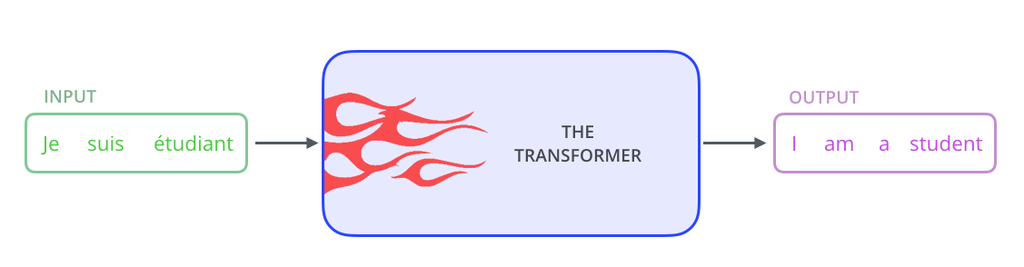

[All image credit to: Jay Alammar](https://jalammar.github.io/illustrated-transformer/)

## Encoder-decoder model

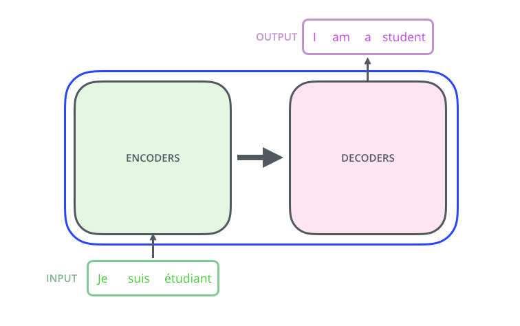

## Stacked encoders and decoders

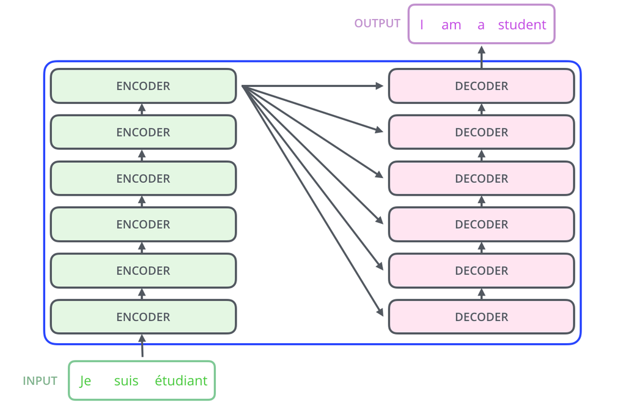

## Attention mechanism

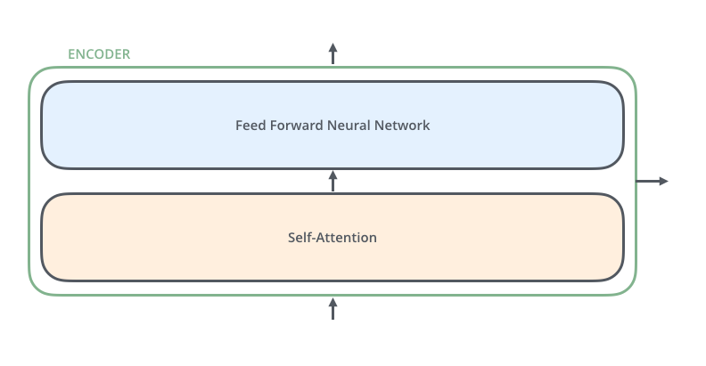

## Autoregressive text generation

Some examples?

## Now: PRACTICAL IV

- working with Glove embeddings
- emotion prediction
- full text classification pipeline

## References

Boyd, Ryan L., A. Ashokkumar, S. Seraj, and J. W. Pennebaker. 2022. “The Development and Psychometric Properties of LIWC-22.” Austin, TX. https://www.liwc.app/.

Brown, Tom, Benjamin Mann, Nick Ryder, Melanie Subbiah, Jared D Kaplan, Prafulla Dhariwal, Arvind Neelakantan, et al. 2020. “Language Models Are Few-Shot Learners.” In *Advances in Neural Information Processing Systems*, edited by H. Larochelle, M. Ranzato, R. Hadsell, M. F. Balcan, and H. Lin, 33:1877–1901. Curran Associates, Inc. https://proceedings.neurips.cc/paper/2020/file/1457c0d6bfcb4967418bfb8ac142f64a-Paper.pdf.

Cer, Daniel, Yinfei Yang, Sheng-yi Kong, Nan Hua, Nicole Limtiaco, Rhomni St. John, Noah Constant, et al. 2018. “Universal Sentence Encoder for English.” In *Proceedings of the 2018 Conference on Empirical Methods in Natural Language Processing: System Demonstrations*, 169–74. Brussels, Belgium: Association for Computational Linguistics. https://doi.org/10.18653/v1/D18-2029.

Devlin, Jacob, Ming-Wei Chang, Kenton Lee, and Kristina Toutanova. 2019. “NAACL-HLT 2019.” In, 41714186. Minneapolis, Minnesota: Association for Computational Linguistics. https://doi.org/10.18653/v1/N19-1423.

Grootendorst, Maarten. 2022. “BERTopic: Neural Topic Modeling with a Class-Based TF-IDF Procedure.” *arXiv Preprint arXiv:2203.05794*.

Harris, Zellig. 1954. “Distributional Hypothesis.” *Word World* 10 (23): 146162.

Kleinberg, Bennett, Isabelle van der Vegt, and Maximilian Mozes. 2020. “Measuring Emotions in the COVID-19 Real World Worry Dataset.” In *Proceedings of the 1st Workshop on NLP for COVID-19 at ACL 2020*. Online: Association for Computational Linguistics. https://www.aclweb.org/anthology/2020.nlpcovid19-acl.11.

Kleinberg, Bennett, and Bruno Verschuere. 2021. “How Humans Impair Automated Deception Detection Performance.” *Acta Psychologica* 213 (February): 103250. https://doi.org/10.1016/j.actpsy.2020.103250.

Mikolov, Tomas, Ilya Sutskever, Kai Chen, Greg Corrado, and Jeffrey Dean. 2013. “Distributed Representations of Words and Phrases and Their Compositionality.” *arXiv:1310.4546 [Cs, Stat]*, October. http://arxiv.org/abs/1310.4546.

Millar, Neil, Bojan Batalo, and Brian Budgell. 2022. “Trends in the Use of Promotional Language (Hype) in Abstracts of Successful National Institutes of Health Grant Applications, 1985-2020.” *JAMA Network Open* 5 (8): e2228676. https://doi.org/10.1001/jamanetworkopen.2022.28676.

Mozes, Maximilian, Isabelle van der Vegt, and Bennett Kleinberg. 2021. “A Repeated-Measures Study on Emotional Responses After a Year in the Pandemic.” *Scientific Reports* 11 (1): 23114. https://doi.org/10.1038/s41598-021-02414-9.

Pennington, Jeffrey, Richard Socher, and Christopher Manning. 2014. “Proceedings of the 2014 Conference on Empirical Methods in Natural Language Processing (EMNLP).” In, 1532–43. Doha, Qatar: Association for Computational Linguistics. https://doi.org/10.3115/v1/D14-1162.

Reimers, Nils, and Iryna Gurevych. 2019. “Proceedings of the 2019 Conference on Empirical Methods in Natural Language Processing and the 9th International Joint Conference on Natural Language Processing (EMNLP-IJCNLP).” In, 3980–90. Hong Kong, China: Association for Computational Linguistics. https://doi.org/10.18653/v1/D19-1410.

Van Der Vegt, Isabelle, and Bennett Kleinberg. 2023. “A Multi-Modal Panel Dataset to Understand the Psychological Impact of the Pandemic.” *Scientific Data* 10 (1): 537. https://doi.org/10.1038/s41597-023-02438-y.

Vaswani, Ashish, Noam Shazeer, Niki Parmar, Jakob Uszkoreit, Llion Jones, Aidan N Gomez, Łukasz Kaiser, and Illia Polosukhin. 2017. “Attention Is All You Need.” *Advances in Neural Information Processing Systems* 30.

Vegt, Isabelle van der, and Bennett Kleinberg. 2020. “Women Worry About Family, Men About the Economy: Gender Differences in Emotional Responses to COVID-19.” In *Social Informatics*, edited by Samin Aref, Kalina Bontcheva, Marco Braghieri, Frank Dignum, Fosca Giannotti, Francesco Grisolia, and Dino Pedreschi, 12467:397–409. Cham: Springer. https://doi.org/10.1007/978-3-030-60975-7_29.